# RNA-seq Report

Alejandro Reyes, asr2878

11/9/2021

This project was conducted to understand how the differences in gene expression between time of collection vary by genotypes of *Arabidopsis thaliana*. This code uses DESeq to identify genes with significant interaction terms between time and genotype. Here is the given descriptions for the genotypes of the plant *Arabidopsis thaliana*: 1. Col wild-type *Arabidopsis thaliana*. 2. 14B a mutant lacking two genes for a plant specific translation initiation factor, eIFiso4G1 (AT5g57870) and eIFiso4G2 (At2g24050). 3. 4G a mutant lacking the one gene for eIF4G (AT3g60240), a translation factor that is more similar to those of other eukaryotes.

```r
source("bio321g_rnaseq_utils.R")
library(BiocParallel)
register(SnowParam(4))
library(DESeq2)
library(ggplot2)
library(pheatmap)
```

# 1.

Initially a DESeqDataSeq object, “dds” was created to test the significance, if any, of the interaction term time:genotype from the genes that had sufficient expression levels. 1429 genes had a significant interaction term (FDR ≤ 0.10). Of these genes, 142.9 are expected to be false discoveries. This was determined by multiplying the number of expected genes (1429) by the false discovery rate (FDR = .10).

```r
dds = DESeqDataSetFromMatrix(
  countData = rnaCounts,
  colData = sampleAnnotation,
  design = ~ time + genotype + time:genotype)
dds = DESeq(dds, test = "LRT", reduced = ~ time + genotype, parallel=TRUE)
interaction_results = results(dds)
interaction_results = interaction_results[order(interaction_results$pvalue),]

testedGenes = which(!is.na(interaction_results$padj))  # actual num of sig tests
# NA implies the gene expression was too low

FDR = .1  # control on padj
numGenesSigIR = sum(interaction_results[testedGenes, "padj"] <= FDR)
numExpectedFalseDiscoveries = numGenesSigIR * FDR
```

# 2.

The normalized counts from dds, after the data was normalized with the DESeq function, were then extracted. These counts were then filtered by removing genes without sufficient data. The data was log2 transformed with an offset of 1 to reduce heteroskedacity.

```r
normed = counts(dds, normalized=TRUE)
normed = normed[rowSums(normed) > 0,] # remove genes with no data
lgNorm = log2(normed + 1) # log transform; satisfies heteroskedacity
```

# 3.

A PCA plot was then constructed using the transformed data. Visually, the samples collected in the dark were most separated from the samples collected in the light along the PC1 direction (dark was oriented in the positive side of the plot while light was negative). Using a similar visual analysis, the Col and 4G genotypes of *Arabidopsis thaliana* were most separated from the 14B genotype along the PC2 direction.

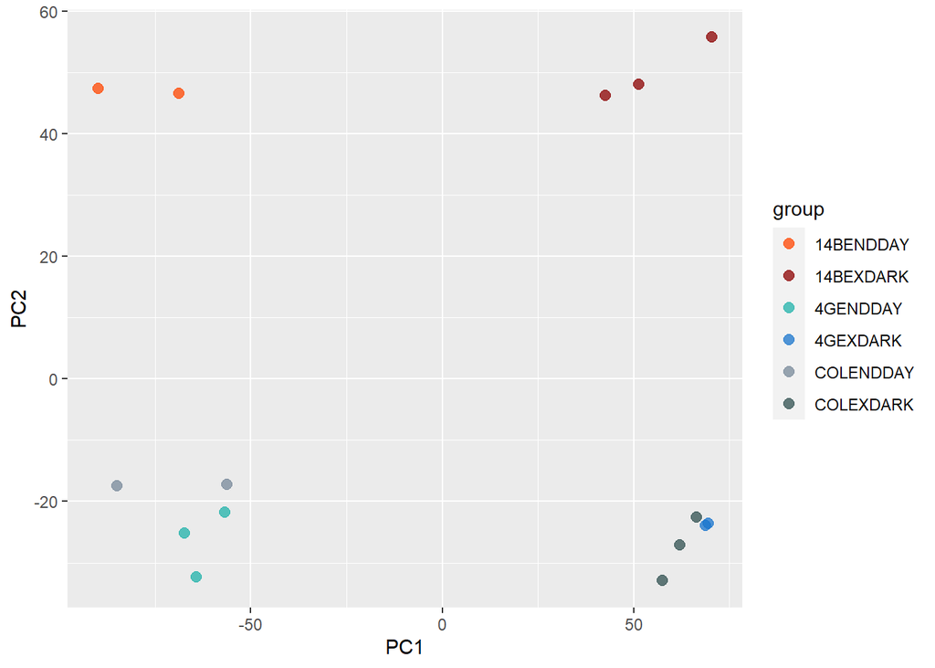

```r
pca_lgNorm = prcomp(t(lgNorm))

pca_lgNorm_annotation = data.frame(
  row.names = colnames(normed),
  group = gsub("^X|\\d$", "", colnames(normed))
)

## set up data.frame pcaData for ggplot...
pcaData = data.frame(pca_lgNorm$x[ , 1:2])
## add in sample annotation info
pcaData$group = pca_lgNorm_annotation[rownames(pcaData), "group"]
## and sample names
pcaData$sample = rownames(pcaData)

gg = ggplot(pcaData, aes(x=PC1, y=PC2, color=group, label=sample))
gg = gg + geom_point(size=2.5, alpha=0.75)
gg = gg + scale_color_manual(values=groupColors)
print(gg)
```

# 4.

A vector was created containing the assigned genes (gene_ontology_primary_id value of GO:0071495). From the assigned genes, the gene ID, gene symbol, and gene description were complied in a tsv file (attached and) named assigned_gene_set.tsv which has been provided.

```r
# get assigned gene set
target_set = goAssociations[goAssociations$gene_ontology_primary_id
                            == "GO:0071495",]
# length of 82

# df with gene id, symbol, and description
assigned_genes = geneNamesAndDescriptions[
                    is.element(geneNamesAndDescriptions$gene, target_set$gene),]
row.names(assigned_genes) = NULL

# write .tsv file
write.table(assigned_genes, file="assigned_gene_set.tsv",
            quote=FALSE, row.names = FALSE, sep="\t")
```

# 5.

The normalized (and transformed) data was further refined to only include the genes assigned.

```r
lgGO = lgNorm[is.element(row.names(lgNorm), target_set$gene),]
```

# 6.

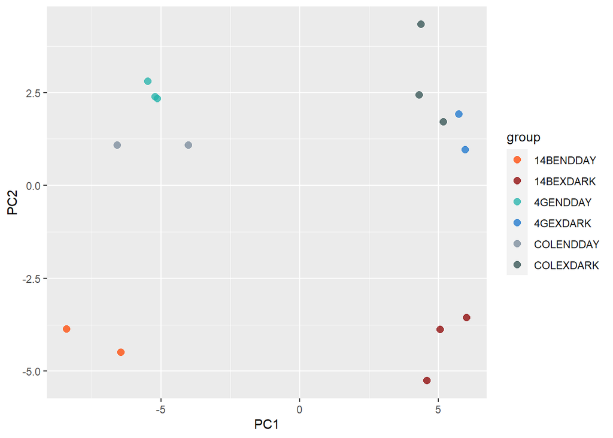

```r
pca_lgGO = prcomp(t(lgGO))
pcaDatalgGO = data.frame(pca_lgGO$x[ , 1:2])
pcaDatalgGO$group = pca_lgNorm_annotation[rownames(pcaDatalgGO), "group"]
pcaDatalgGO$sample = rownames(pcaDatalgGO)
gg2 = ggplot(pcaDatalgGO, aes(x=PC1, y=PC2, color=group, label=sample))
gg2 = gg2 + geom_point(size=2.5, alpha=0.75)
gg2 = gg2 + scale_color_manual(values=groupColors)
print(gg2)
```

# 7.

The differences in the log-transformed normalized expression level and the mean expression level of each of these genes were stored in heatData. A clustered heatmap was then constructed using this data and the pheatmap function. The expression level in heatData was limited by setting values greater than 2 equal to 2 and values less than -2 equal to -2. This was done to make the resulting pheatmap more readable and to prevent the overabundance of a few individual colors.

The two largest clusters were found in the upper left and right corners of the heatmap. The genes in the upper left corner of the heatmap have mostly low expression. It is interesting to note that these samples were all collected in the light and were independent of the genotype. The genes in the upper right corner of the heatmap have an above average rate of expression. These samples were also independent of genotype but were dependent on the time of collection being dark. The LHCB2.2 gene was highly expressed when the sample was collected in the dark and inhibited when collected in the light. There were also two more clusters that formed on the lower corners of the heatmap. They showed an inverse relationship of expression and time of collection than that of the two larger clusters mentioned previously.

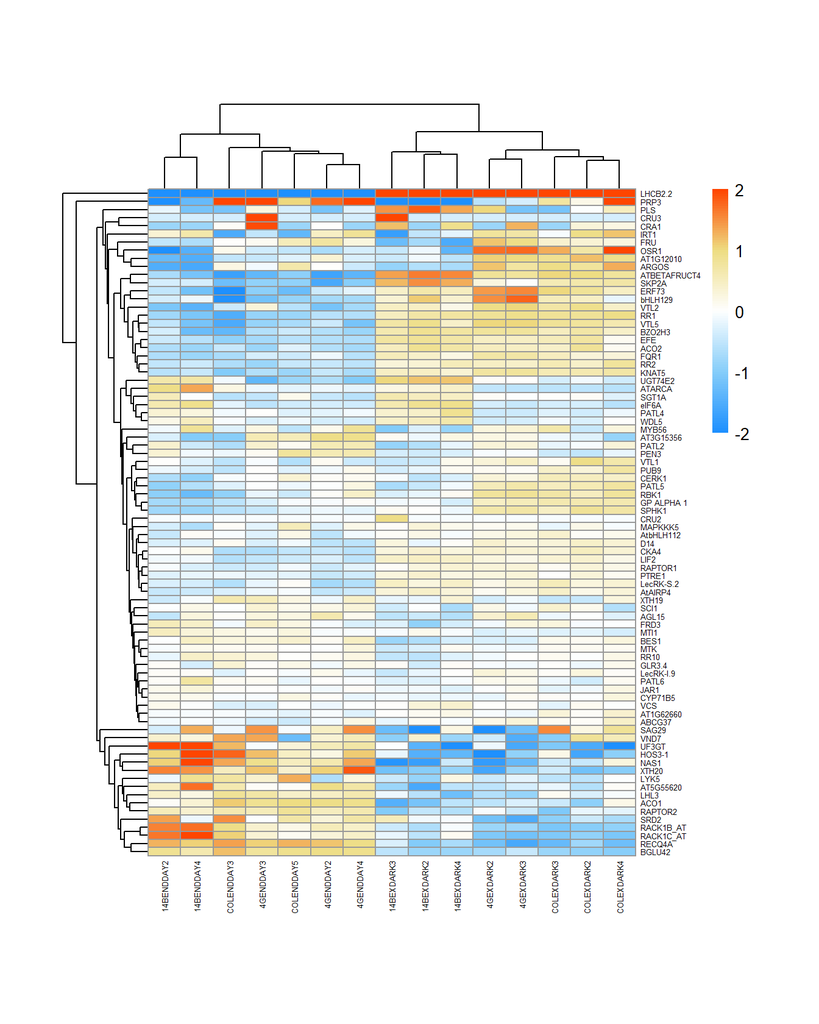

```r
heatData = lgGO - rowMeans(lgGO)
heatData[heatData > 2] = 2; heatData[heatData < -2] = -2
# help("pheatmap")
pheatmap(
  heatData,
  heatPalette,
  clustering_method = "average",
  # show_rownames = FALSE,
  labels_row=geneNamesAndDescriptions[rownames(heatData), "symbol"],
  cellheight = 5,
  cellwidth = 20,
  fontsize_row = 5,
  fontsize_col = 5,
  angle_col = 90
)
```

# 8.

Lastly, the lgGO data was filtered by the lowest interaction term (time:genotype) according to pvalues in the DESeq results of the dds object. The 9 genes with this lowest interaction term were then used to construct a stripchart with the provided stripchart321g function.

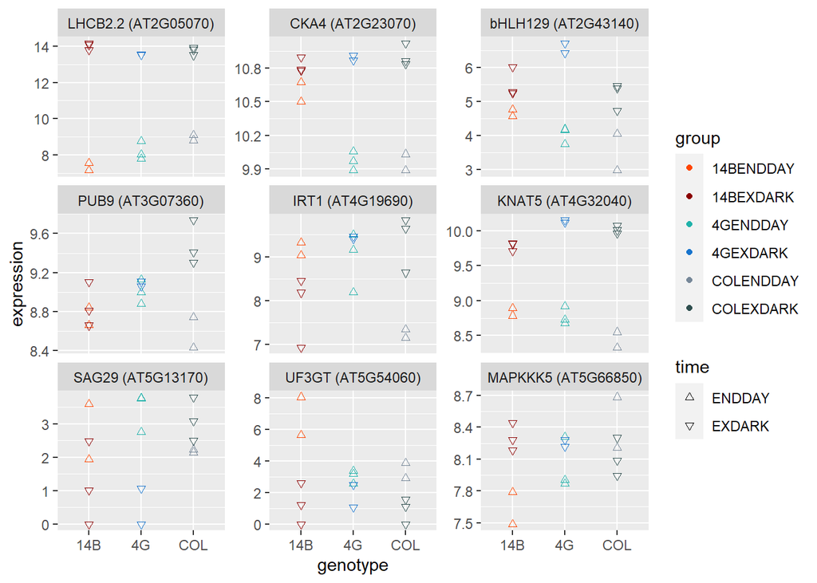

```r
# use previous deseq results but only include assigned genes
# top 9 genes with the smallest p values
reduced_DESeq = interaction_results[is.element(row.names(interaction_results),
                                              target_set$gene), ]
reduced_DESeq = reduced_DESeq[order(reduced_DESeq$pvalue), ]
reduced_DESeq = reduced_DESeq[1:9, ]
reduced_lgGO = lgGO[is.element(row.names(lgGO), row.names(reduced_DESeq)), ]
stripchart_rlgGO = stripchart321g(
                                  reduced_lgGO,
                                  sampleAnnotation,
                                  geneNames = geneNamesAndDescriptions,
                                  colorValues = groupColors)
stripchart_rlgGO
```